# HW1

Sila Aydin

05 10 2018

## Reading and Preprocessing

The preprocessing part is taken from the example solved in the data.table example

## Task 1 A

### Betsson

#### Betsson Initial

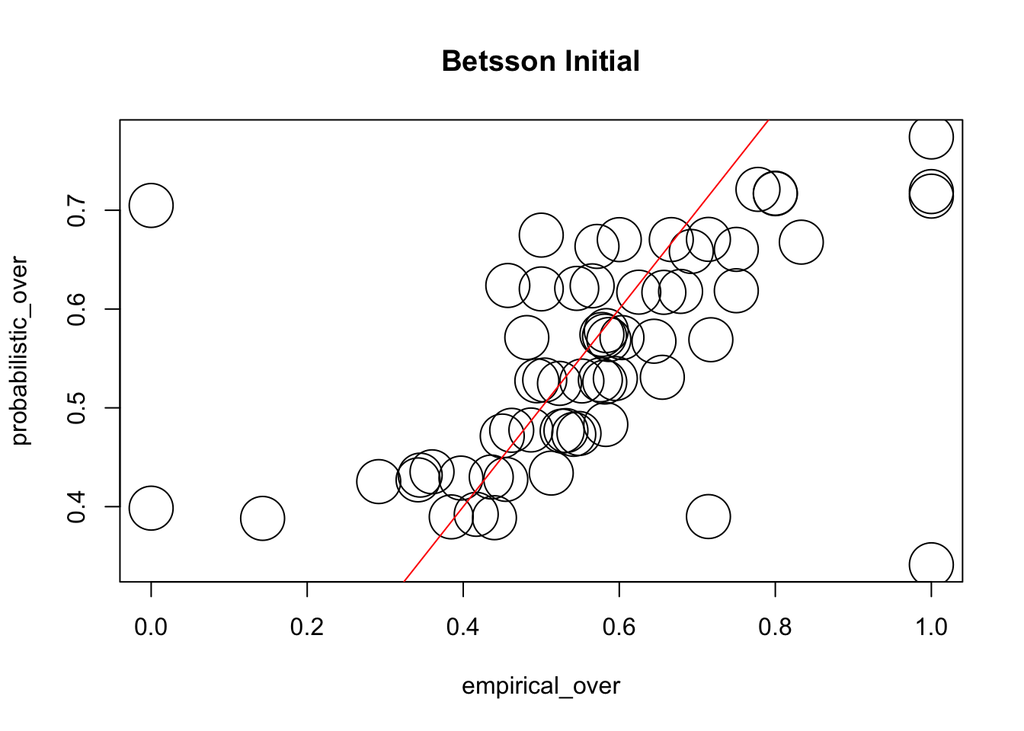

```r
plot(summary_table[,list(empirical_over,probabilistic_over)],cex=4)
abline(0,1,col='red')
title("Betsson Initial")
```

#### Betsson Final

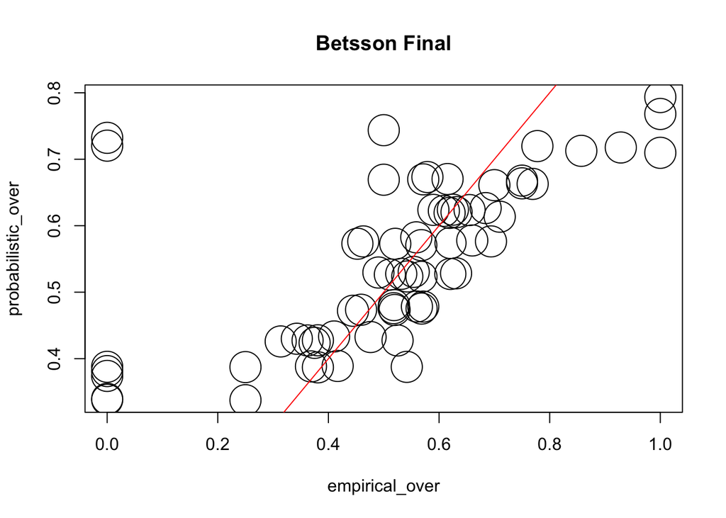

```r
plot(summary_table[,list(empirical_over,probabilistic_over)],cex=4)
abline(0,1,col='red')
title("Betsson Final")
```

### 1xBet

#### 1xBet Initial

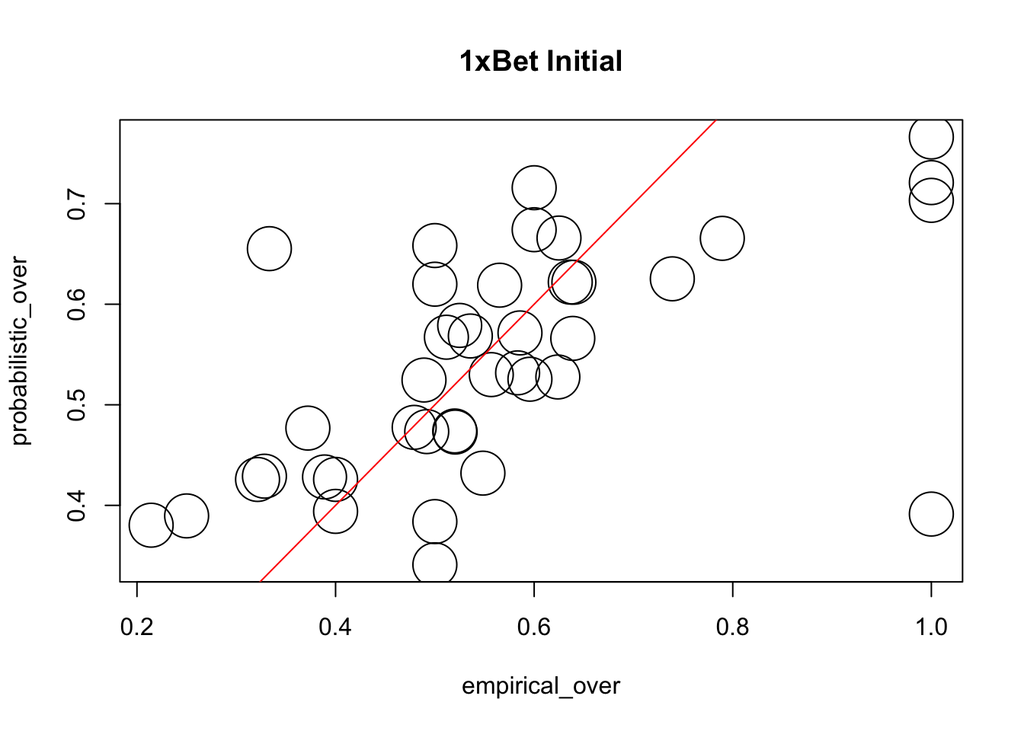

```r
plot(summary_table[,list(empirical_over,probabilistic_over)],cex=4)
abline(0,1,col='red')
title("1xBet Initial")
```

#### 1xBet Final

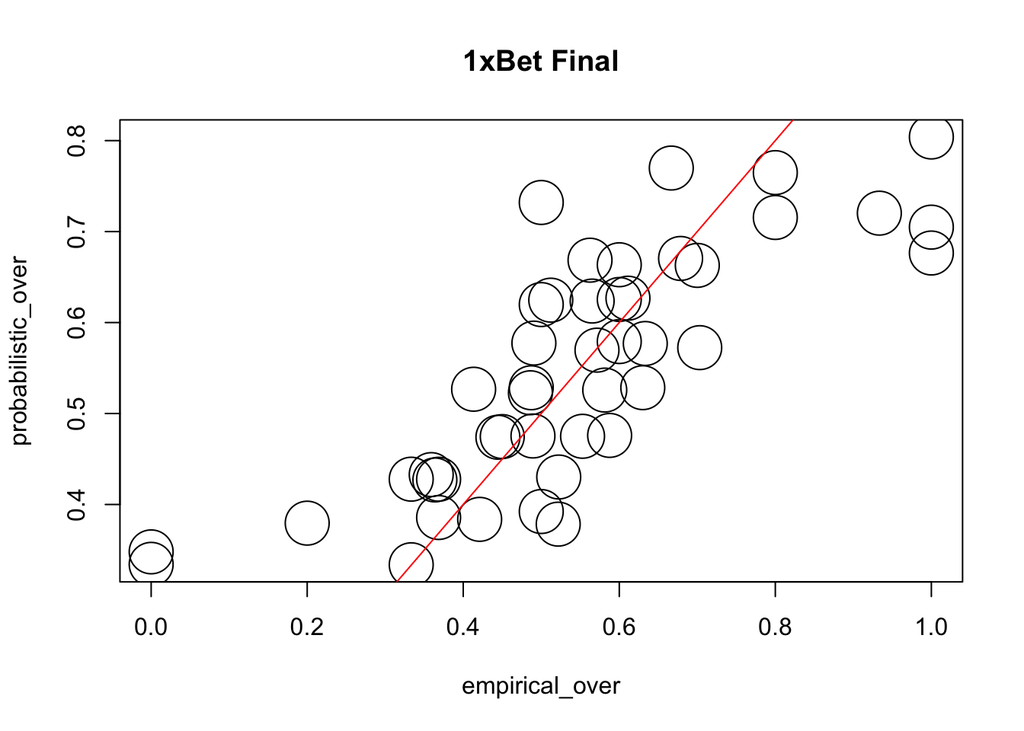

```r
plot(summary_table[,list(empirical_over,probabilistic_over)],cex=4)
abline(0,1,col='red')
title("1xBet Final")
```

### Unibet

#### Unibet Initial

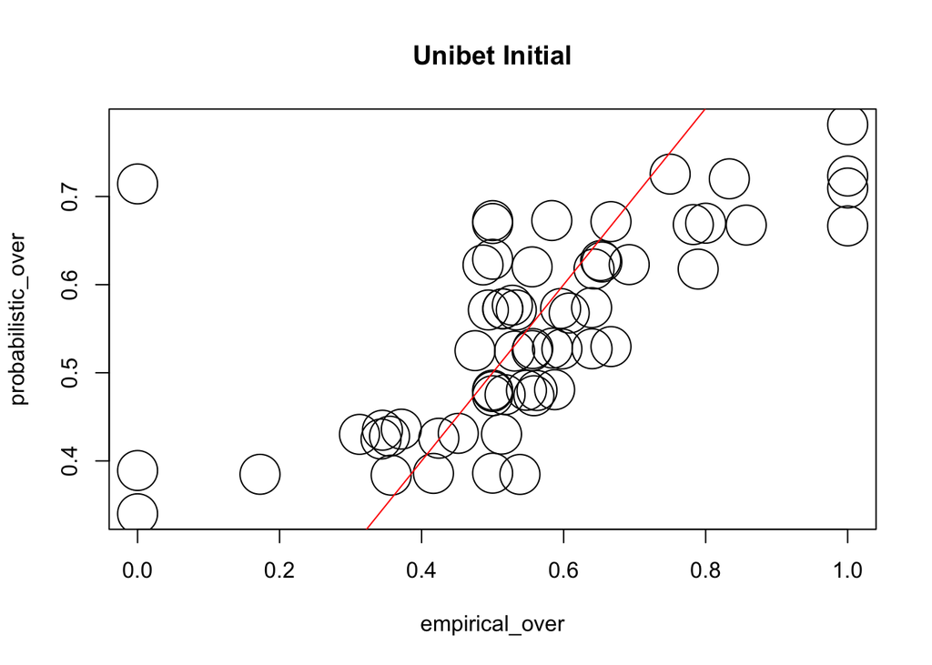

```r
plot(summary_table[,list(empirical_over,probabilistic_over)],cex=4)
abline(0,1,col='red')
title("Unibet Initial")
```

#### Unibet Final

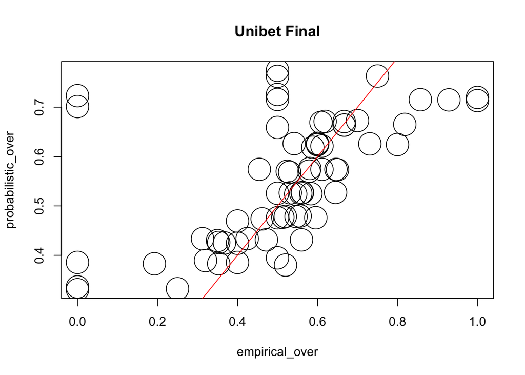

```r
plot(summary_table[,list(empirical_over,probabilistic_over)],cex=4)
abline(0,1,col='red')
title("Unibet Final")
```

### Expekt

#### Expekt Initial

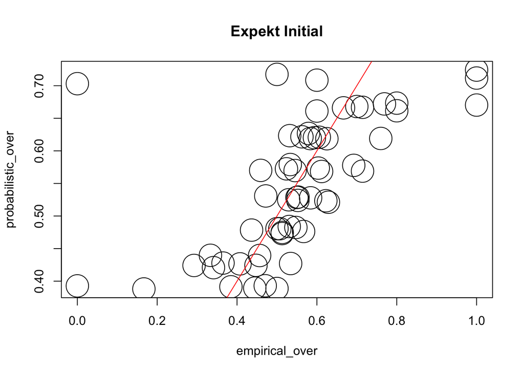

```r
plot(summary_table[,list(empirical_over,probabilistic_over)],cex=4)
abline(0,1,col='red')
title("Expekt Initial")
```

#### Expekt Final

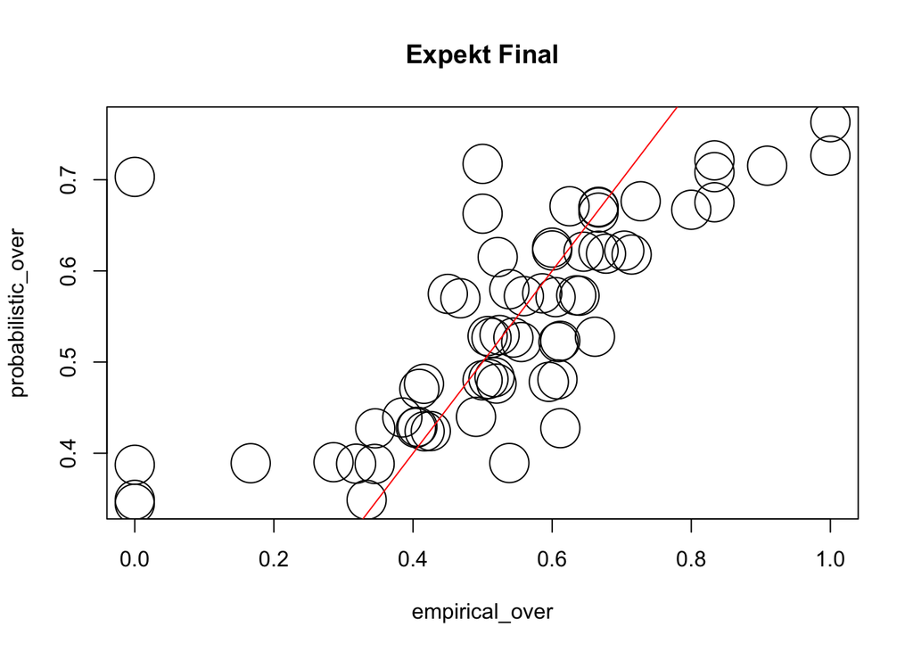

```r
plot(summary_table[,list(empirical_over,probabilistic_over)],cex=4)
abline(0,1,col='red')
title("Expekt Final")
```

### Tipico

#### Tipico Initial

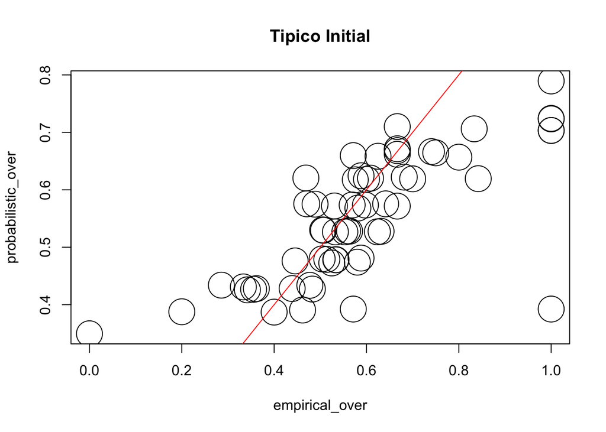

```r
plot(summary_table[,list(empirical_over,probabilistic_over)],cex=4)
abline(0,1,col='red')
title("Tipico Initial")
```

#### Tipico Final

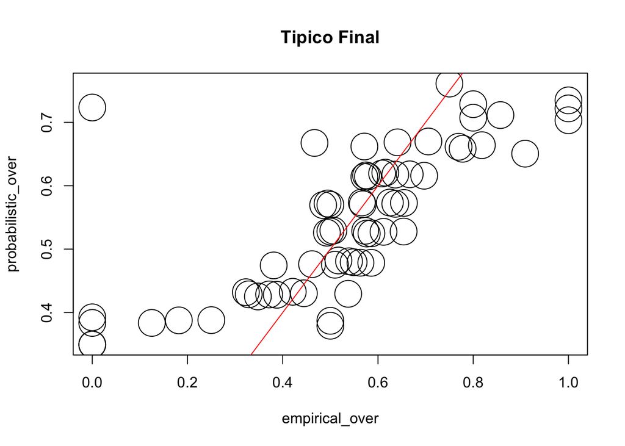

```r
plot(summary_table[,list(empirical_over,probabilistic_over)],cex=4)
abline(0,1,col='red')
title("Tipico Final")
```

## Task 1 B with Expekt

Here the body code is taken from the code solved in the PS

For Task 1 B I chose the bookmaker Expekt and divided the bins to have 0.1 intervals. The probabilities have a range in (0.3, 0.7]. There 4 graphs for 4 different bins. I used the final odds for each match to show the odds over the years.

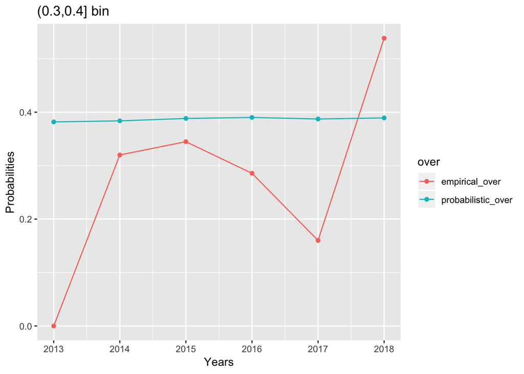

```r
summary_table2=melt(summary_table, id=c("Year", "odd_cut_over"), measure=c("empirical_over","probabilistic_over"), variable.name = "over")
ggplot(summary_table2[odd_cut_over=="(0.3,0.4]"], aes(x=Year, y=value, color=over))+geom_line()+geom_point(aes(y=value))+labs(title="(0.3,0.4] bin", x="Years", y="Probabilities")
```

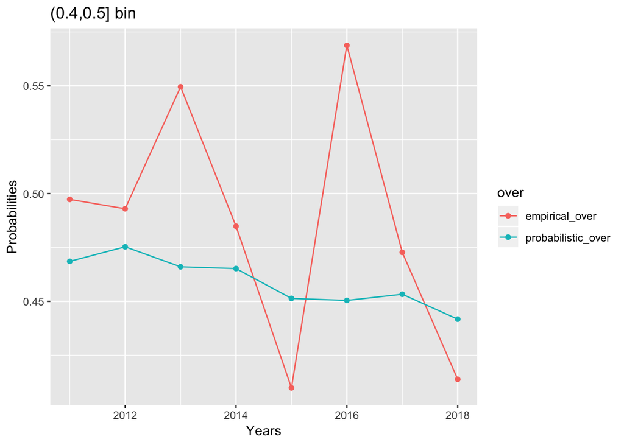

```r
ggplot(summary_table2[odd_cut_over=="(0.4,0.5]"],  aes(x=Year, y=value, color=over))+geom_line()+geom_point(aes(y=value))+labs(title="(0.4,0.5] bin", x="Years", y="Probabilities")
```

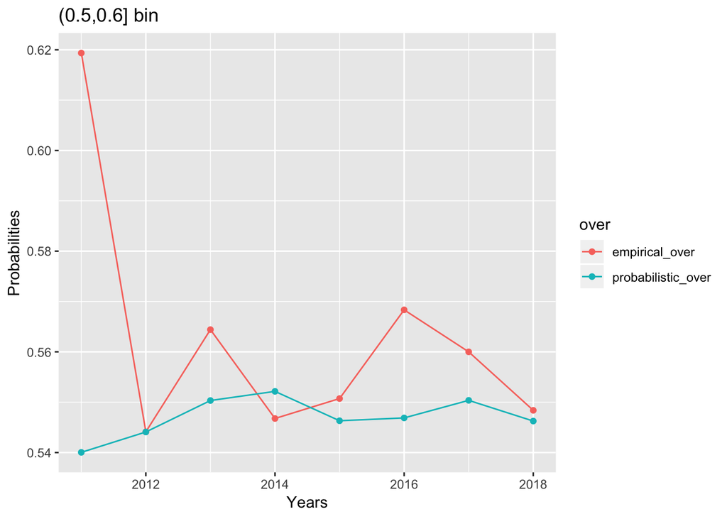

```r
ggplot(summary_table2[odd_cut_over=="(0.5,0.6]"],  aes(x=Year, y=value, color=over))+geom_line()+geom_point(aes(y=value))+labs(title="(0.5,0.6] bin", x="Years", y="Probabilities")
```

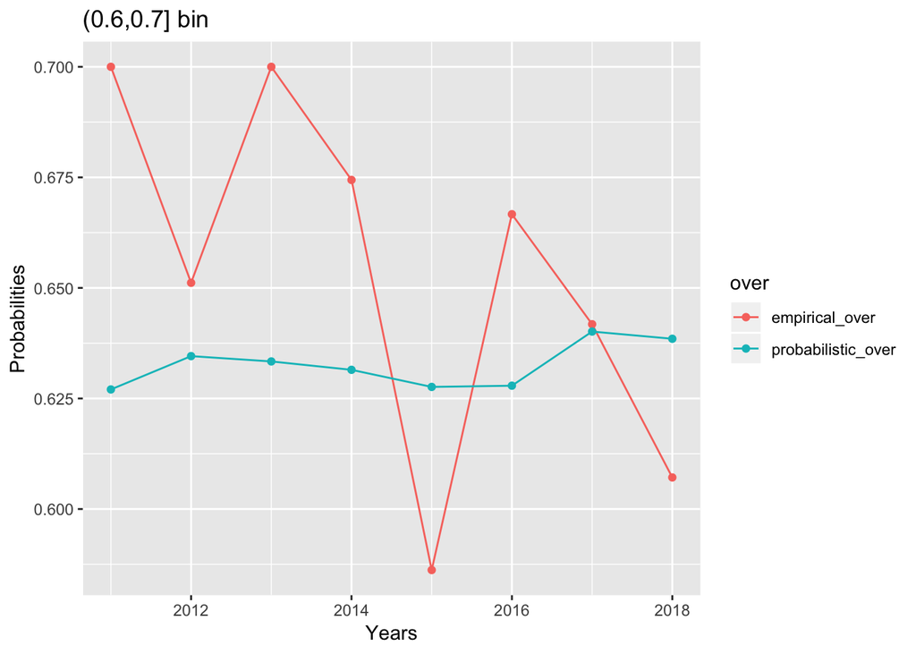

```r
ggplot(summary_table2[odd_cut_over=="(0.6,0.7]"],  aes(x=Year, y=value, color=over))+geom_line()+geom_point(aes(y=value))+labs(title="(0.6,0.7] bin", x="Years", y="Probabilities")
```

## Task 2

In this task I chose different matches according to the differences of the scores. I looked at Home wins, Away wins and the games that ends as Draw. I wanted to look at games where the score difference is large (more than 5 and less than -3). Positive score difference indicates Home wins. I thought in general when the score difference is large the result of the game is more predictable than other games. Large score difference can indicate one of the teams (team 1) is much stronger than the other team (team 2) which should make the odds for team 2 very high

```r
matchestask2[, c("ScoreDifference"):= (HomeScore-AwayScore)]

#choose betType 1x2 and bookmaker 1xBet
odd_ch=odds[betType=="1x2"& bookmaker=="1xBet"]
odd_ch[,date:=anydate(date)]

#to see matches, bookmakers, total scores and score differences in one table
merged_changes=merge(matchestask2[,list(ScoreDifference, TotalScore, matchId)],odd_ch[,list(bookmaker, odd, matchId),], by="matchId")

#Home wins by far
merged_changes[ScoreDifference>5,bookmaker,by=.(matchId)] #choose matchID = 4zO9Zo1S
```

```
##      matchId bookmaker
##  1: 4zO9Zo1S     1xBet
##  2: 4zO9Zo1S     1xBet
##  3: 4zO9Zo1S     1xBet
##  4: 4zO9Zo1S     1xBet
##  5: 4zO9Zo1S     1xBet
##  6: 4zO9Zo1S     1xBet
##  7: ANkPsLHF     1xBet
##  8: ANkPsLHF     1xBet
##  9: ANkPsLHF     1xBet
## 10: ANkPsLHF     1xBet
## 11: ANkPsLHF     1xBet
## 12: ANkPsLHF     1xBet
```

```r
merged_changes[ScoreDifference==1,bookmaker,by=.(matchId)] #choose matchID = 0ED3uC4P
```

```
##         matchId bookmaker
##     1: 0ED3uC4P     1xBet
##     2: 0ED3uC4P     1xBet
##     3: 0ED3uC4P     1xBet
##     4: 0ED3uC4P     1xBet
##     5: 0ED3uC4P     1xBet
##    ---
## 11731: zR0yOf1N     1xBet
## 11732: zR0yOf1N     1xBet
## 11733: zR0yOf1N     1xBet
## 11734: zR0yOf1N     1xBet
## 11735: zR0yOf1N     1xBet
```

```r
#Away wins by far
merged_changes[ScoreDifference<(-3),bookmaker,by=.(matchId)] #choose matchID = 2mBn8m87
```

```
##       matchId bookmaker
##   1: 2mBn8m87     1xBet
##   2: 2mBn8m87     1xBet
##   3: 2mBn8m87     1xBet
##   4: 2mBn8m87     1xBet
##   5: 2mBn8m87     1xBet
##  ---
## 454: rw9dmtVJ     1xBet
## 455: rw9dmtVJ     1xBet
## 456: rw9dmtVJ     1xBet
## 457: rw9dmtVJ     1xBet
## 458: rw9dmtVJ     1xBet
```

```r
merged_changes[ScoreDifference==(-1),bookmaker,by=.(matchId)] #choose matchID = zskawz1A
```

```
##        matchId bookmaker
##    1: 004f4ING     1xBet
##    2: 004f4ING     1xBet
##    3: 004f4ING     1xBet
##    4: 004f4ING     1xBet
##    5: 004f4ING     1xBet
##   ---
## 9115: zskawz1A     1xBet
## 9116: zskawz1A     1xBet
## 9117: zskawz1A     1xBet
## 9118: zskawz1A     1xBet
## 9119: zskawz1A     1xBet
```

```r
#Draw
merged_changes[ScoreDifference==0,bookmaker,by=.(matchId)] #choose matchID = 06H610QA
```

```
##         matchId bookmaker
##     1: 06H610QA     1xBet
##     2: 06H610QA     1xBet
##     3: 06H610QA     1xBet
##     4: 06H610QA     1xBet
##     5: 06H610QA     1xBet
##    ---
## 14911: zylytbNg     1xBet
## 14912: zylytbNg     1xBet
## 14913: zylytbNg     1xBet
## 14914: zylytbNg     1xBet
## 14915: zylytbNg     1xBet
```

```r
#Too many goals in one game
merged_changes[TotalScore>=8,bookmaker,by=.(matchId)] #choose matchID = vei0UAHB
```

```
##       matchId bookmaker
##   1: 233M67kh     1xBet
##   2: 233M67kh     1xBet
##   3: 233M67kh     1xBet
##   4: 233M67kh     1xBet
##   5: 233M67kh     1xBet
##  ---
## 342: vei0UAHB     1xBet
## 343: vei0UAHB     1xBet
## 344: vei0UAHB     1xBet
## 345: vei0UAHB     1xBet
## 346: vei0UAHB     1xBet
```

#### Home wins by 6

First I look at a case where the home team wins by 6. If the home team is known to be stronger than the away team and the result is not unexpected, the expectation is to finds “odd1” low and “odd2” high.

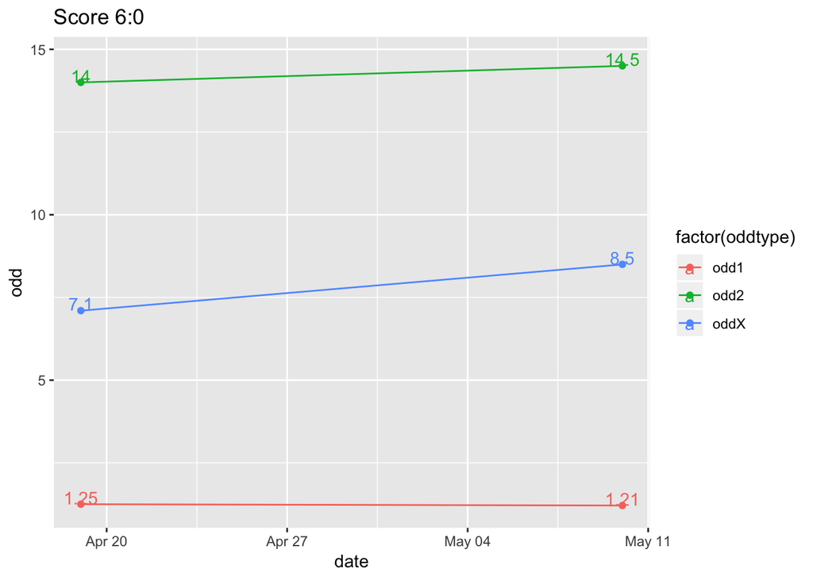

```r
ggplot(odd_ch[matchId=="4zO9Zo1S", ], aes(date, odd, color=factor(oddtype)))+geom_line()+geom_point(aes(y=odd))+geom_text(aes(label=odd), nudge_y=0.2)+labs(title="Score 6:0")
```

As expected “odd2” is very high compared to “odd1”. There is no significant change in the odds in time.

##### Home wins by 1

This is a case where the Home team wins by 1. Here the odds are expected to be close to each other. If the bookmaker is good at determining probabilities the expectation is that she gives higher odds for the Away team winning (odd2).

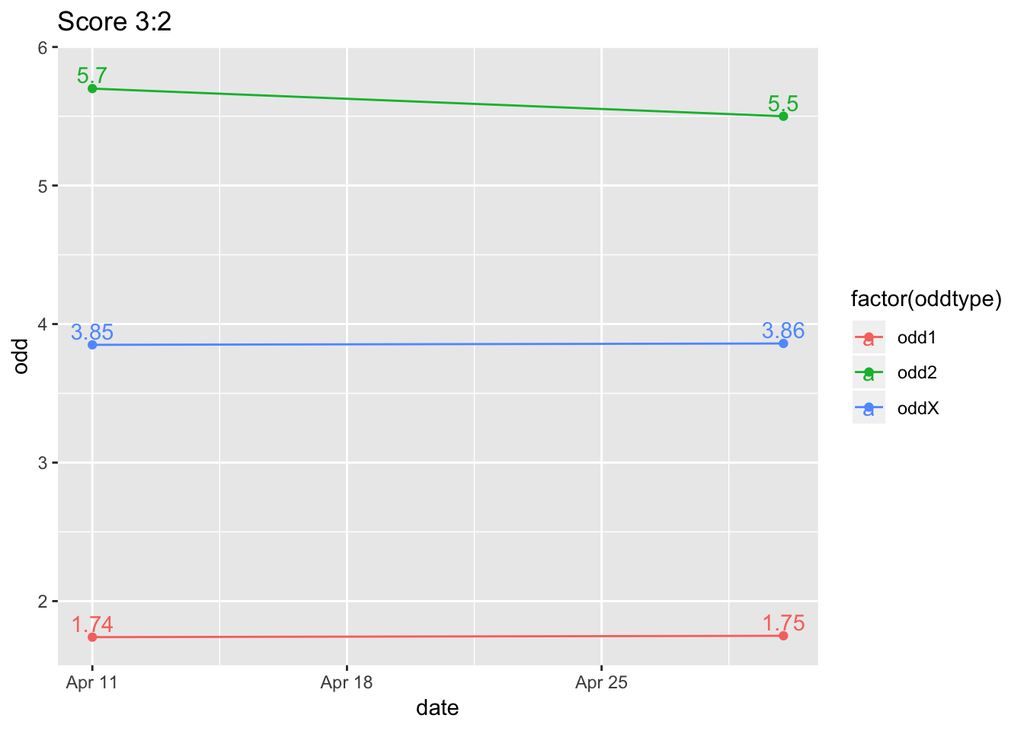

```r
ggplot(odd_ch[matchId=="0ED3uC4P",], aes(date, odd, color=factor(oddtype)))+geom_line()+geom_point(aes(y=odd))+geom_text(aes(label=odd), nudge_y=0.1)+labs(title="Score 3:2")
```

The odds are not very close and odd2 is higher than the other odds. Eventhough the scores are close, the bookmaker did a good job in determining the probabilities.

#### Away team wins by 4

This is a case where the Away team beats the Home team by 4 goals. The expectation is to find odd1 high.

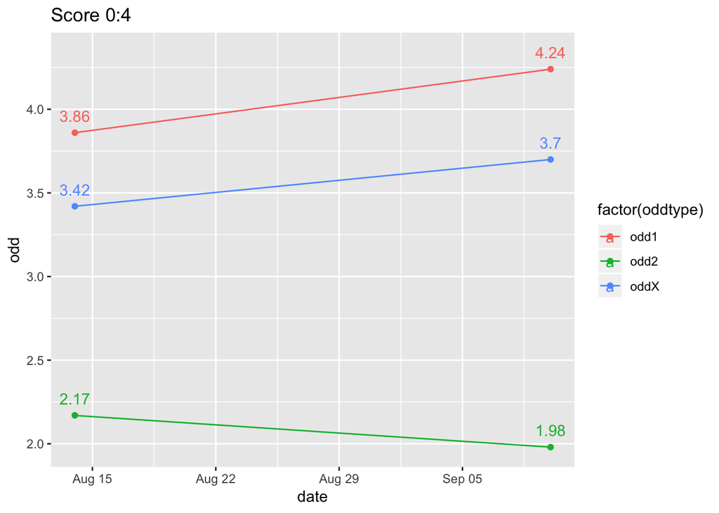

```r
ggplot(odd_ch[matchId=="2mBn8m87",], aes(date, odd, color=factor(oddtype)))+geom_line()+geom_point(aes(y=odd))+geom_text(aes(label=odd), nudge_y=0.1)+labs(title="Score 0:4")
```

The odds for Away team winning are low as expected. The decrease in odd2 and triggers an increase in odd1 and oddX.

#### Away team wins by 1

In this case the Away team wins by 1. This difference indicates that the teams are matching in strength, if the bookmaker is good at determining probabilities she would give higher odds for the Home team winning. THe expectation is to find odds close to each other

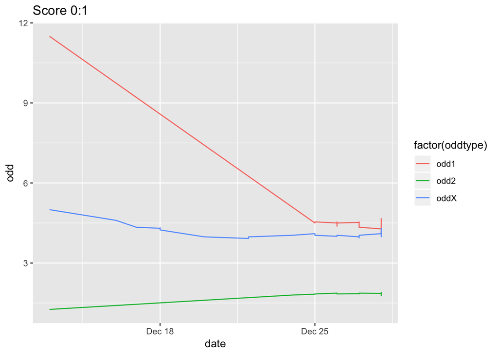

```r
#points and labels are removed from this plot beacuse it gets messy
ggplot(odd_ch[matchId=="0Ea58aKB",], aes(date, odd, color=factor(oddtype)))+geom_line()+labs(title="Score 0:1")
```

Odd1 starts out very high and it remains higher as time passes which is expected but it also drops rapidly. This may indicate that the Home team displayed good performance during this time. There is a lot of change on the odds after December 25.

#### Draw

Here I look at a case where the match ends in tie. I expect to find the odds changing too much in time and close to each other.

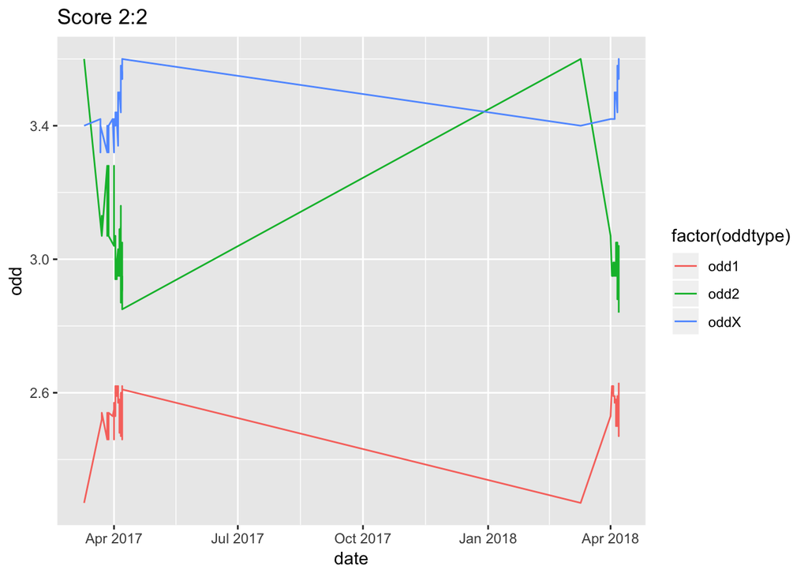

```r
#points and labels are removed from this plot beacuse it gets messy
ggplot(odd_ch[matchId=="06H610QA",], aes(date, odd, color=factor(oddtype)))+geom_line()+labs(title="Score 2:2")
```

The odds are changing very much and the betting for this match started 1 year in advance. In previous graphs oddX was always in the middle but here it is generally higher than the other odds. It can be observed that the home team was expected to win 1 month before the game but there are some last minute changes in favor of the Away team. Still in the end, the game was expected to end with a Home win with low probability for a draw.

#### Too many goals in one game

This is a game that ends with 9 goals and score difference is 1. I wanted to see how the odds were changing for this case as well.

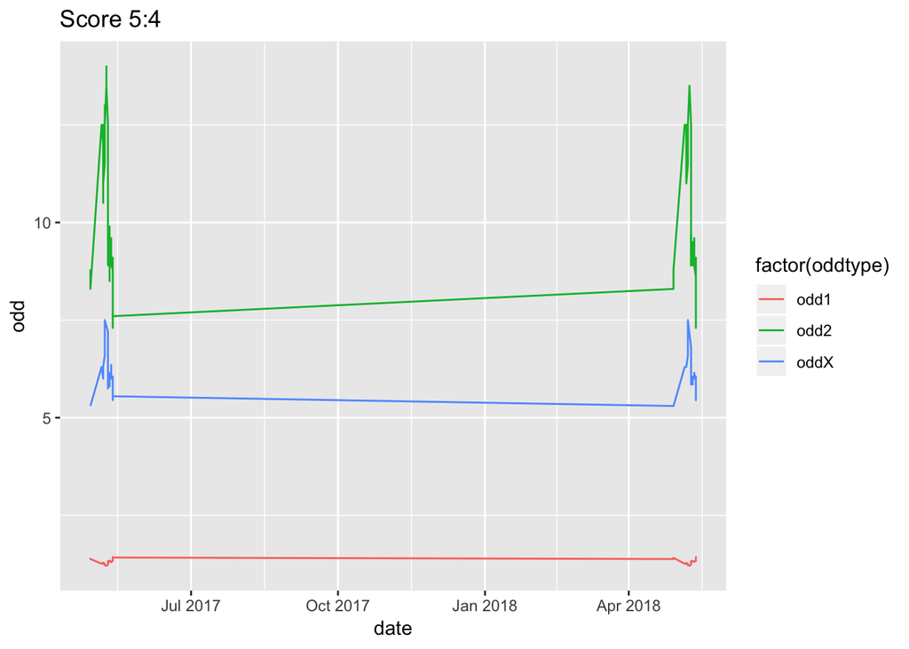

```r
ggplot(odd_ch[matchId=="vei0UAHB",], aes(date, odd, color=factor(oddtype)))+geom_line()+labs(title="Score 5:4")
```